# Maryville Data Science Project 2018

MengChu Tsai

September 17, 2018

Reset System and working directory

```r
#clear the memor
rm (list =ls())
graphics.off()
#Reset graph Parameters
old.par <- par(mar = c(0, 0, 0, 0))
par(old.par)
#set working directory
setwd("C:/Users/jokae/Desktop")
```

Read dataset into R

```r
library(readr)
dataset <- read_csv("insurance.csv")
str(dataset)
```

```
## Classes 'tbl_df', 'tbl' and 'data.frame':    1338 obs. of  8 variables:
##  $ age     : int  19 18 28 33 32 31 46 37 37 60 ...
##  $ sex     : chr  "female" "male" "male" "male" ...
##  $ gender  : int  1 0 0 0 0 1 1 1 0 1 ...
##  $ bmi     : num  27.9 33.8 33 22.7 28.9 ...
##  $ children: int  0 1 3 0 0 0 1 3 2 0 ...
##  $ smoker  : chr  "yes" "no" "no" "no" ...
##  $ region  : chr  "southwest" "southeast" "southeast" "northwest" ...
##  $ charges : num  16885 1726 4449 21984 3867 ...
##  - attr(*, "spec")=List of 2
##   ..$ cols   :List of 8
##   .. ..$ age     : list()
##   .. .. ..- attr(*, "class")= chr  "collector_integer" "collector"
##   .. ..$ sex     : list()
##   .. .. ..- attr(*, "class")= chr  "collector_character" "collector"
##   .. ..$ gender  : list()
##   .. .. ..- attr(*, "class")= chr  "collector_integer" "collector"
##   .. ..$ bmi     : list()
##   .. .. ..- attr(*, "class")= chr  "collector_double" "collector"
##   .. ..$ children: list()
##   .. .. ..- attr(*, "class")= chr  "collector_integer" "collector"
##   .. ..$ smoker  : list()
##   .. .. ..- attr(*, "class")= chr  "collector_character" "collector"
##   .. ..$ region  : list()
##   .. .. ..- attr(*, "class")= chr  "collector_character" "collector"
##   .. ..$ charges : list()
##   .. .. ..- attr(*, "class")= chr  "collector_double" "collector"
##   ..$ default: list()
##   .. ..- attr(*, "class")= chr  "collector_guess" "collector"
##   ..- attr(*, "class")= chr "col_spec"
```

check data structure

```r
str(dataset)
```

```
## Classes 'tbl_df', 'tbl' and 'data.frame':    1338 obs. of  8 variables:
##  $ age     : int  19 18 28 33 32 31 46 37 37 60 ...
##  $ sex     : chr  "female" "male" "male" "male" ...
##  $ gender  : int  1 0 0 0 0 1 1 1 0 1 ...
##  $ bmi     : num  27.9 33.8 33 22.7 28.9 ...
##  $ children: int  0 1 3 0 0 0 1 3 2 0 ...
##  $ smoker  : chr  "yes" "no" "no" "no" ...
##  $ region  : chr  "southwest" "southeast" "southeast" "northwest" ...
##  $ charges : num  16885 1726 4449 21984 3867 ...
##  - attr(*, "spec")=List of 2
##   ..$ cols   :List of 8
##   .. ..$ age     : list()
##   .. .. ..- attr(*, "class")= chr  "collector_integer" "collector"
##   .. ..$ sex     : list()
##   .. .. ..- attr(*, "class")= chr  "collector_character" "collector"
##   .. ..$ gender  : list()
##   .. .. ..- attr(*, "class")= chr  "collector_integer" "collector"
##   .. ..$ bmi     : list()
##   .. .. ..- attr(*, "class")= chr  "collector_double" "collector"
##   .. ..$ children: list()
##   .. .. ..- attr(*, "class")= chr  "collector_integer" "collector"
##   .. ..$ smoker  : list()
##   .. .. ..- attr(*, "class")= chr  "collector_character" "collector"
##   .. ..$ region  : list()
##   .. .. ..- attr(*, "class")= chr  "collector_character" "collector"
##   .. ..$ charges : list()
##   .. .. ..- attr(*, "class")= chr  "collector_double" "collector"
##   ..$ default: list()
##   .. ..- attr(*, "class")= chr  "collector_guess" "collector"
##   ..- attr(*, "class")= chr "col_spec"
```

refomat data

```r
################change categorical variables to factors###########################
factors_dataset <- c("sex", "gender", "children", "smoker","region")
dataset[factors_dataset]<-lapply(dataset[factors_dataset], function (x) as.factor(x))
str(dataset)
```

```
## Classes 'tbl_df', 'tbl' and 'data.frame':    1338 obs. of  8 variables:
##  $ age     : int  19 18 28 33 32 31 46 37 37 60 ...
##  $ sex     : Factor w/ 2 levels "female","male": 1 2 2 2 2 1 1 1 2 1 ...
##  $ gender  : Factor w/ 2 levels "0","1": 2 1 1 1 1 2 2 2 1 2 ...
##  $ bmi     : num  27.9 33.8 33 22.7 28.9 ...
##  $ children: Factor w/ 6 levels "0","1","2","3",..: 1 2 4 1 1 1 2 4 3 1 ...
##  $ smoker  : Factor w/ 2 levels "no","yes": 2 1 1 1 1 1 1 1 1 1 ...
##  $ region  : Factor w/ 4 levels "northeast","northwest",..: 4 3 3 2 2 3 3 2 1 2 ...
##  $ charges : num  16885 1726 4449 21984 3867 ...
##  - attr(*, "spec")=List of 2
##   ..$ cols   :List of 8
##   .. ..$ age     : list()
##   .. .. ..- attr(*, "class")= chr  "collector_integer" "collector"
##   .. ..$ sex     : list()
##   .. .. ..- attr(*, "class")= chr  "collector_character" "collector"
##   .. ..$ gender  : list()
##   .. .. ..- attr(*, "class")= chr  "collector_integer" "collector"
##   .. ..$ bmi     : list()
##   .. .. ..- attr(*, "class")= chr  "collector_double" "collector"
##   .. ..$ children: list()
##   .. .. ..- attr(*, "class")= chr  "collector_integer" "collector"
##   .. ..$ smoker  : list()
##   .. .. ..- attr(*, "class")= chr  "collector_character" "collector"
##   .. ..$ region  : list()
##   .. .. ..- attr(*, "class")= chr  "collector_character" "collector"
##   .. ..$ charges : list()
##   .. .. ..- attr(*, "class")= chr  "collector_double" "collector"
##   ..$ default: list()
##   .. ..- attr(*, "class")= chr  "collector_guess" "collector"
##   ..- attr(*, "class")= chr "col_spec"
```

Data Cleaning

```r
############   duplicate analysis  ################
library(dplyr)
#number of original dataset
original <- dim(dataset)[[1]]
#select dictinct row
dataset <- distinct(dataset)
# check # of duplicates
dup <- original-dim(dataset)[[1]]
print(paste0("the number of duplicates=",dup))
```

```
## [1] "the number of duplicates=1"
```

Missing Value Analysis

```r
# check missing count in each feature
missing.value.count <- sapply(dataset, function(x) sum(is.na(x)))
missing.value.count
```

```
##      age      sex   gender      bmi children   smoker   region  charges
##        1        2        4        2        0        0        0        0
```

```r
# Visiulization of missing data
#pdf("missing.pdf")
library(VIM)
```

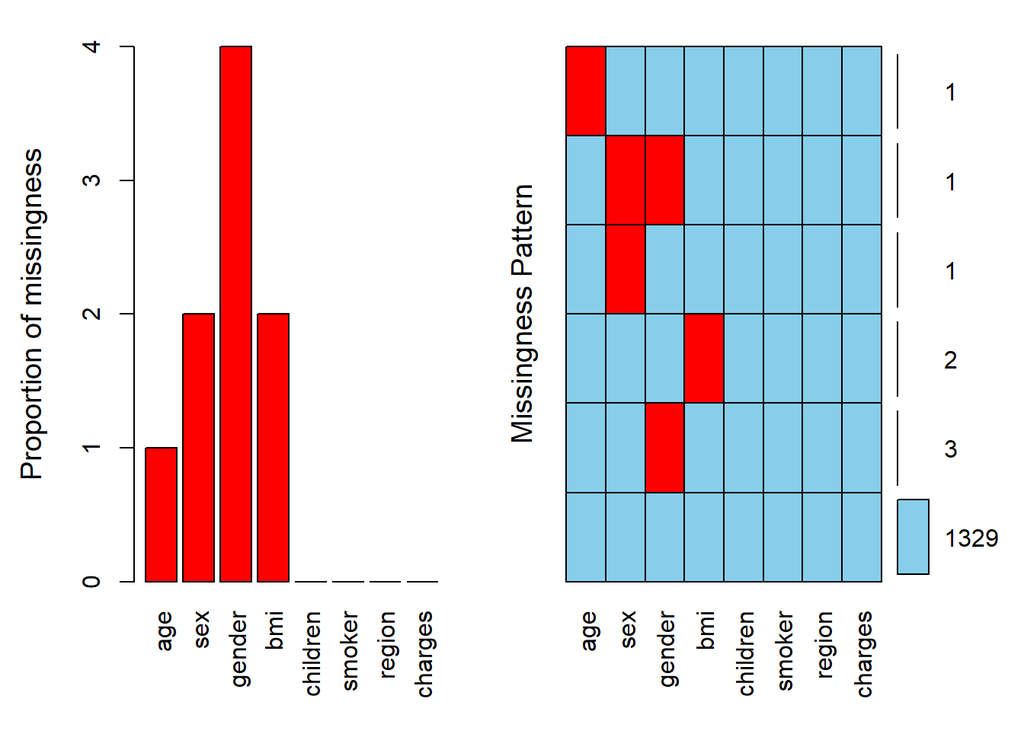

```r
aggr(dataset, prop = F, numbers = T, cex.axis=1, cex.numbers = 1,
     ylab=c("Proportion of missingness","Missingness Pattern"),
     labels=names(dataset))
```

```r
#dev.off()
```

Since we have large number of observations in the dataset and we will use all the classes of the varaibles in the training process, the model doesn’t lose power evenif we eliminate missing values. Besides, avoiding imputation for missing data also helps us not to introduce unnecessary bias (meaning, disproportionate or non-representation of classes) in our model. Therefor we will set na.action=na.omit to exclude thes from our study.

Delete Missing Values

```r
#Delete Missing Values
dataset <- dataset[complete.cases(dataset), ]
# check missing count in new dataset
missing.value.count <- sapply(dataset, function(x) sum(is.na(x)))
missing.value.count
```

```
##      age      sex   gender      bmi children   smoker   region  charges
##        0        0        0        0        0        0        0        0
```

Redundancy Analysis one of the features of multicollinearity is that the standard errors of the affected coefficients tend to be large. In that case, the test of the hypothesis that the coefficient is equal to zero may lead to a failure to reject a false null hypothesis of no effect of the explanator, a type II error. Another issue with multicollinearity is that small changes to the input data can lead to large changes in the model, even resulting in changes of sign of parameter estimates. A principal danger of such data redundancy is that of overfitting in regression analysis models.

```r
#check redudance
library(Hmisc)
redun( ~ age+sex+gender+bmi+children+smoker+region  ,r2 = 0.5, data  = dataset)
```

```
##
## Redundancy Analysis
##
## redun(formula = ~age + sex + gender + bmi + children + smoker +
##     region, data = dataset, r2 = 0.5)
##
## n: 1329  p: 7    nk: 3
##
## Number of NAs:    0
##
## Transformation of target variables forced to be linear
##
## R-squared cutoff: 0.5    Type: ordinary
##
## R^2 with which each variable can be predicted from all other variables:
##
##      age      sex   gender      bmi children   smoker   region
##    0.020    1.000    1.000    0.101    0.149    0.018    0.100
##
## Rendundant variables:
##
## sex
##
## Predicted from variables:
##
## age gender bmi children smoker region
##
##   Variable Deleted R^2 R^2 after later deletions
## 1              sex   1
```

Result indicates sex and gender are perfectly correlated so sex will be remove from our dateset

```r
#remove sex from dataset
dataset <- dataset[c(-2)]
```

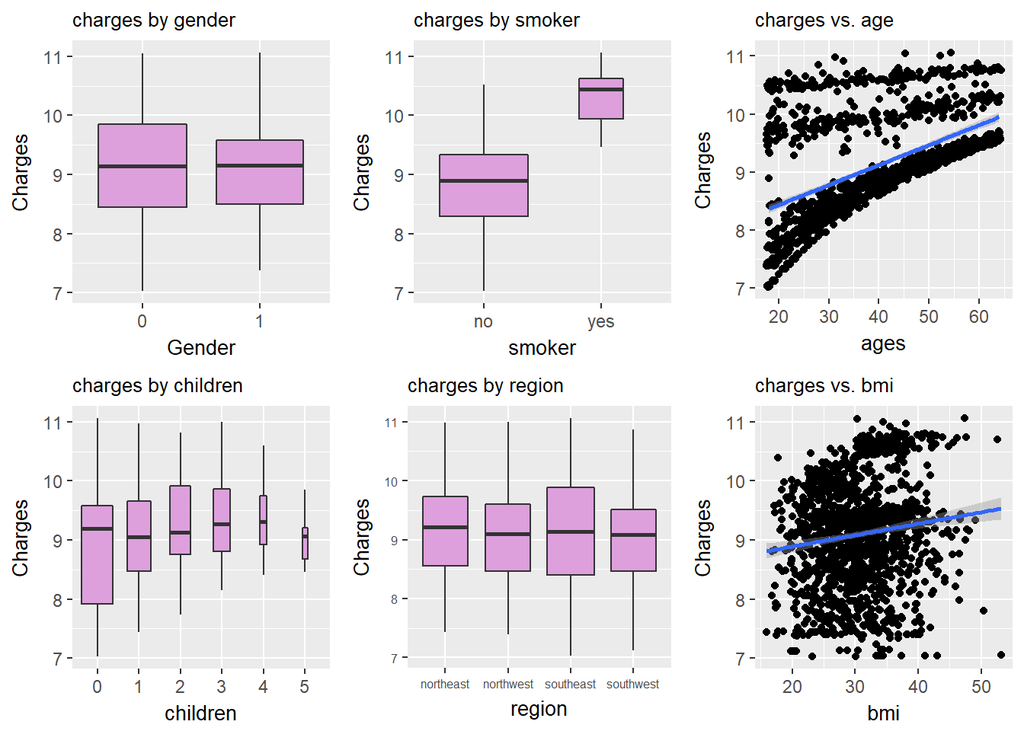

```r
# Multiple plot function
#
# ggplot objects can be passed in ..., or to plotlist (as a list of ggplot objects)
# - cols:   Number of columns in layout
# - layout: A matrix specifying the layout. If present, 'cols' is ignored.
#
# If the layout is something like matrix(c(1,2,3,3), nrow=2, byrow=TRUE),
# then plot 1 will go in the upper left, 2 will go in the upper right, and
# 3 will go all the way across the bottom.
#
multiplot <- function(..., plotlist=NULL, file, cols=1, layout=NULL) {
  require(grid)

  # Make a list from the ... arguments and plotlist
  plots <- c(list(...), plotlist)

  numPlots = length(plots)

  # If layout is NULL, then use 'cols' to determine layout
  if (is.null(layout)) {
    # Make the panel
    # ncol: Number of columns of plots
    # nrow: Number of rows needed, calculated from # of cols
    layout <- matrix(seq(1, cols * ceiling(numPlots/cols)),
                     ncol = cols, nrow = ceiling(numPlots/cols))
  }

  if (numPlots==1) {
    print(plots[[1]])

  } else {
    # Set up the page
    grid.newpage()
    pushViewport(viewport(layout = grid.layout(nrow(layout), ncol(layout))))

    # Make each plot, in the correct location
    for (i in 1:numPlots) {
      # Get the i,j matrix positions of the regions that contain this subplot
      matchidx <- as.data.frame(which(layout == i, arr.ind = TRUE))

      print(plots[[i]], vp = viewport(layout.pos.row = matchidx$row,
                                      layout.pos.col = matchidx$col))
    }
  }
}
################### scatter plots and boxplots to exam relationship between variables ##########
#pdf("Descriptive_Analysis.pdf")
log_charges <- log(dataset$charges)
g1 <- ggplot(dataset, aes(gender,log_charges))
g11 <- g1 + geom_boxplot(varwidth=T, fill="plum") +
  labs(
       subtitle="charges by gender",
       x="Gender",
       y="Charges")+
       theme(axis.title=element_text(size=10))

g2 <- ggplot(dataset, aes(children,log_charges))
g22 <- g2 + geom_boxplot(varwidth=T, fill="plum") +
  labs(
       subtitle="charges by children",
       x="children",
       y="Charges")+
      theme(axis.title=element_text(size=10))

g3 <- ggplot(dataset, aes(smoker,log_charges))
g33 <- g3 + geom_boxplot(varwidth=T, fill="plum") +
  labs(
       subtitle="charges by smoker",
       x="smoker",
       y="Charges")+
        theme(axis.title=element_text(size=10))

g4 <- ggplot(dataset, aes(region,log_charges))
g44 <- g4 + geom_boxplot(varwidth=T, fill="plum") +
  labs(
       subtitle="charges by region",
       x="region",
       y="Charges")+
       theme(axis.text=element_text(size=6),
        axis.title=element_text(size=10))

g5 <- ggplot(dataset, aes(age,log_charges))
g55 <- g5 + geom_jitter()+
     geom_smooth(method=lm)+
     labs(
       subtitle="charges vs. age",
       x="ages",
       y="Charges")+
        theme(axis.title=element_text(size=10))

g6 <- ggplot(dataset, aes(bmi,log_charges))
g66 <- g6 + geom_jitter()+
     geom_smooth(method=lm)+
     labs(
       subtitle="charges vs. bmi",
       x="bmi",
       y="Charges")+
        theme(axis.title=element_text(size=10))

multiplot(g11,g22,g33,g44,g55,g66, cols=3)
```

```r
#dev.off()
```

distribution of response variable (Check Normality)

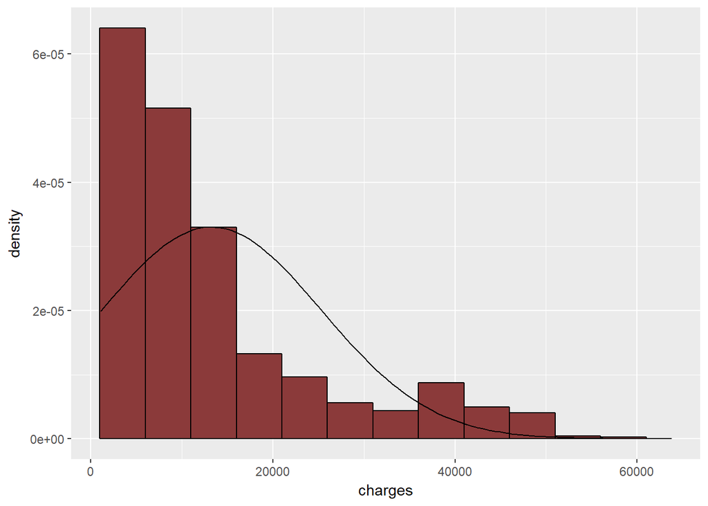

```r
####################  Histogram of Charges (Response Variable) ###############
#summary(dataset$charges)
#pdf("hist_Charges.pdf")
ggplot(dataset, aes(x = charges)) +
    geom_histogram(aes(y =..density..),
                   breaks = seq(1000, 65000, by = 5000),
                   colour = "black",
                   fill = "indianred4") +
    stat_function(fun = dnorm,
                  args = list(mean = mean(dataset$charges),
                  sd = sd(dataset$charges)))
```

```r
#dev.off()
```

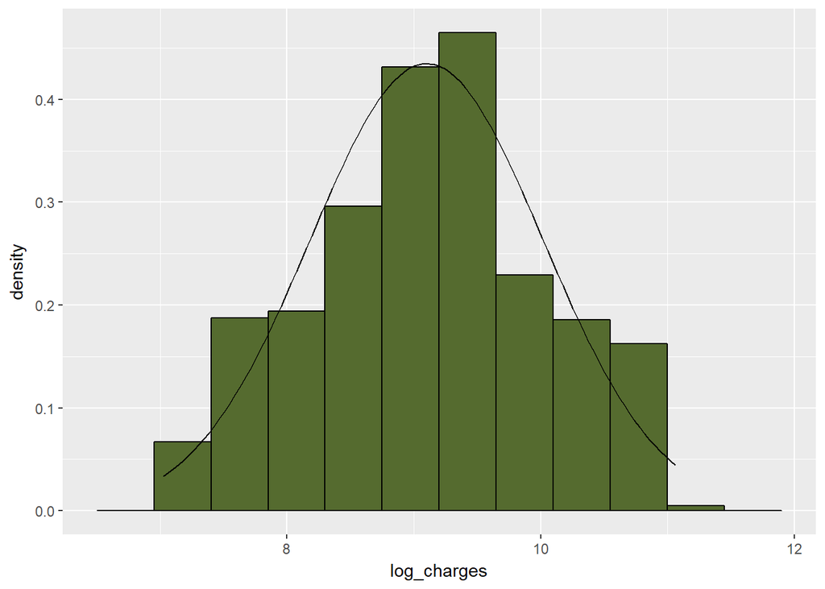

```r
##################### Response variable transformation #####################
#pdf("hist_Charges_trans.pdf")
log_charges <- log(dataset$charges)
ggplot(dataset, aes(x = log_charges)) +
    geom_histogram(aes(y =..density..),
                   breaks = seq(6.5, 12, by =0.45),
                   colour = "black",
                   fill = "darkolivegreen") +
    stat_function(fun = dnorm,
                  args = list(mean = mean(log_charges),
                  sd = sd(log_charges)))
```

```r
#dev.off()
```

Create train and test set

```r
#Split data into train and test sets
library(caret)
set.seed(54321)
indexes <- createDataPartition(dataset$charges,
                               times = 1,
                               p = 0.7,
                               list=FALSE)

dataset.train <- dataset[indexes,]
dataset.test <- dataset[-indexes,]
```

Set parameter for k-Fold Cross Validation

```r
#set up 3 times 10 fold repeated cross-validation
library(caret)
set.seed(54321)
train.control <- trainControl(method = "repeatedcv",
                              number = 10,
                              repeats = 3
                              )
```

```r
################################## Linear Regression Model ###############################################
caret.lm <- train(log(charges) ~ age+gender+bmi+children+smoker+region+age:children,
                  data = dataset.train,
                  method = "lm",
                  preProcess = c("center", "scale"),
                  trControl = train.control
                  )
caret.lm$finalModel
```

```
##
## Call:
## lm(formula = .outcome ~ ., data = dat)
##
## Coefficients:
##     (Intercept)              age          gender1              bmi
##        9.105450         0.510611         0.035884         0.087081
##       children1        children2        children3        children4
##        0.050810         0.244558         0.180926         0.149608
##       children5        smokeryes  regionnorthwest  regionsoutheast
##        0.060412         0.645364        -0.028445        -0.079766
## regionsouthwest  `age:children1`  `age:children2`  `age:children3`
##       -0.057957        -0.002425        -0.167946        -0.113489
## `age:children4`  `age:children5`
##       -0.082031        -0.003532
```

```r
########################## Random Forest Model ####################################
caret.rf <- train(log(charges) ~ age+gender+bmi+children+smoker+region,
                  data = dataset.train,
                  method = "rf",
                  importance=T,
                  preProcess = c("center", "scale"),
                  trControl = train.control
                  )
caret.rf
```

```
## Random Forest
##
## 933 samples
##   6 predictor
##
## Pre-processing: centered (12), scaled (12)
## Resampling: Cross-Validated (10 fold, repeated 3 times)
## Summary of sample sizes: 840, 839, 840, 839, 841, 839, ...
## Resampling results across tuning parameters:
##
##   mtry  RMSE       Rsquared   MAE
##    2    0.4779162  0.8178569  0.3659689
##    7    0.3776791  0.8253924  0.2017853
##   12    0.3881554  0.8163352  0.2089783
##
## RMSE was used to select the optimal model using the smallest value.
## The final value used for the model was mtry = 7.
```

```r
##################################  Linear support vector machine  #########################################
#support vector machine with linear kernel
caret.svm.lm <- train(log(charges) ~ age+gender+bmi+children+smoker+region,
                  data = dataset.train,
                  method = "svmLinear",
                  preProcess = c("center", "scale"),
                  trControl = train.control
                  )
caret.svm.lm
```

```
## Support Vector Machines with Linear Kernel
##
## 933 samples
##   6 predictor
##
## Pre-processing: centered (12), scaled (12)
## Resampling: Cross-Validated (10 fold, repeated 3 times)
## Summary of sample sizes: 841, 839, 840, 839, 840, 841, ...
## Resampling results:
##
##   RMSE       Rsquared   MAE
##   0.4507353  0.7709699  0.2501906
##
## Tuning parameter 'C' was held constant at a value of 1
```

```r
################################## non-linear support vector machine  #########################################
#support vector machine with non-linear kernel
caret.svm.nlm <- train(log(charges) ~ age+gender+bmi+children+smoker+region,
                  data = dataset.train,
                  method = "svmRadial",
                  preProcess = c("center", "scale"),
                  trControl = train.control
                  )
```

```r
################################## Gradient boosted decision trees  #########################################
#xgboost
library(xgboost)
caret.xgb <- train(log(charges) ~ age+gender+bmi+children+smoker+region,
                  data = dataset.train,
                  method = "xgbTree",
                  importance=T,
                  preProcess = c("center", "scale"),
                  trControl = train.control
                  )

#caret.xgb
```

Model Selection

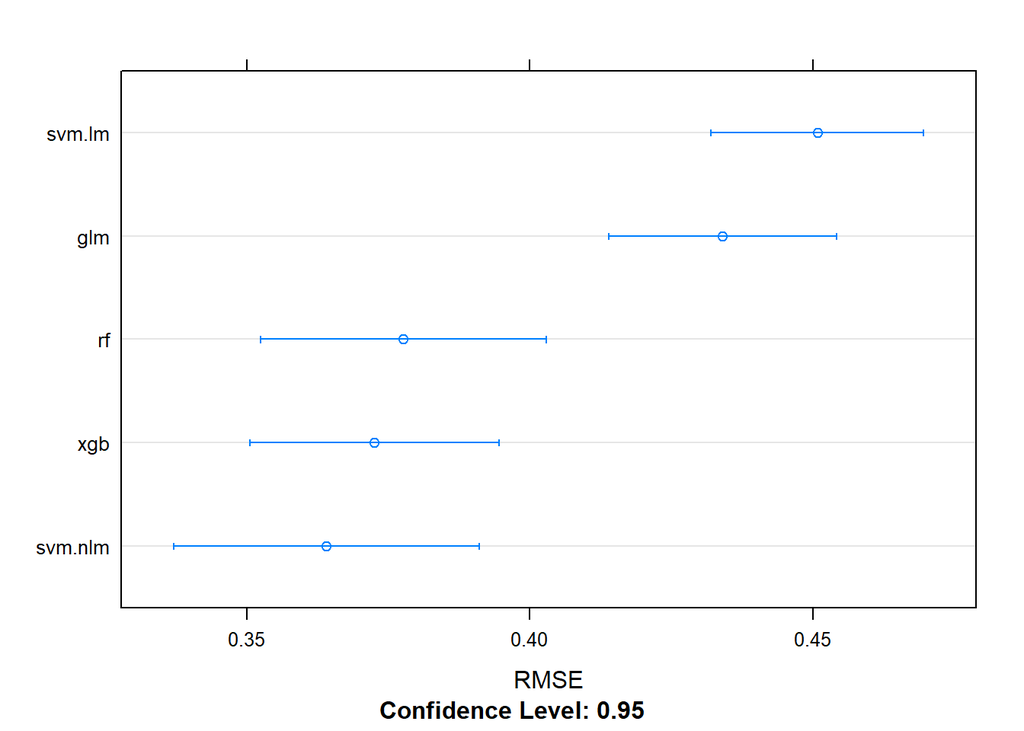

```r
############################ Model Comparison using resampleing ###########################
results <- resamples(list(glm=caret.lm, rf=caret.rf, svm.lm=caret.svm.lm,
                          svm.nlm=caret.svm.nlm, xgb=caret.xgb))
# The resamples function in caret collates the resampling results from the two models
#pdf("Comparison_resampling.pdf")
par(mfrow=c(1,3))
dotplot(results, metric = "RMSE",cex=1.5)
```

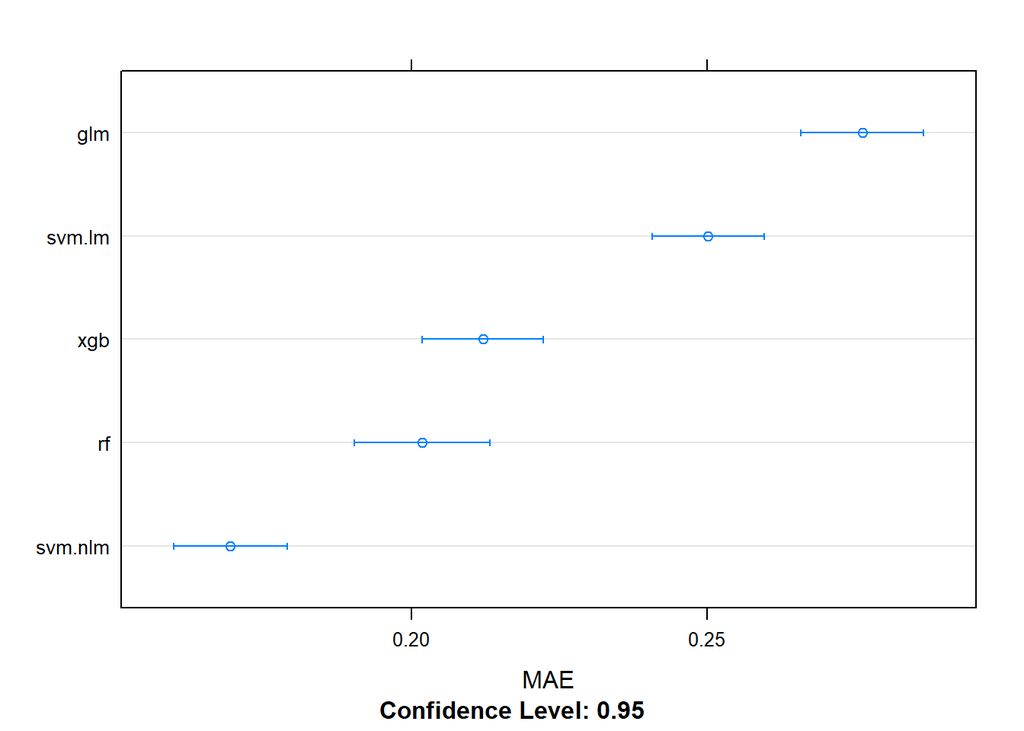

```r
dotplot(results, metric = "MAE")
```

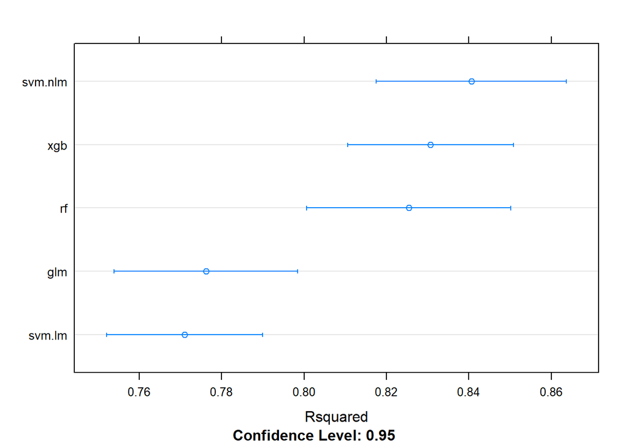

```r
dotplot(results, metric = "Rsquared")
```

```r
#dev.off()
```

```r
#####################   Model Comparison using test sets  ###############
dataset.test$charges.log <- log(dataset.test$charges)

pred.rf <- predict(caret.rf, dataset.test)
rmse.rf = sqrt(mean((pred.rf - dataset.test$charges.log)^2))
rmse.rf
```

```
## [1] 0.4182658
```

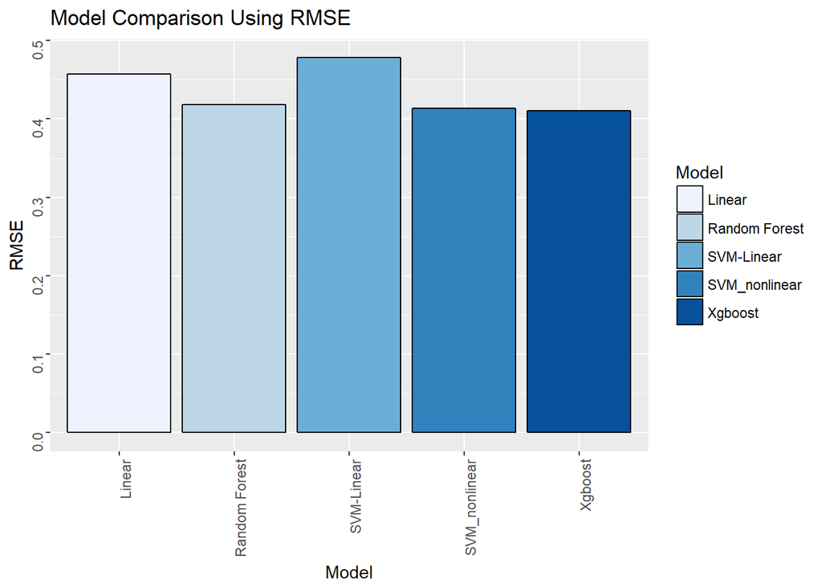

```r
pred.lm <- predict(caret.lm, dataset.test)
rmse.lm = sqrt(mean((pred.lm - dataset.test$charges.log)^2))

pred.svm.lm<- predict(caret.svm.lm, dataset.test)
rmse.svm.lm = sqrt(mean((pred.svm.lm - dataset.test$charges.log)^2))

pred.svm.nlm<- predict(caret.svm.nlm, dataset.test)
rmse.svm.nlm = sqrt(mean((pred.svm.nlm - dataset.test$charges.log)^2))

pred.xgb<- predict(caret.xgb, dataset.test)
rmse.xgb = sqrt(mean((pred.xgb - dataset.test$charges.log)^2))

# Assign names to x
x <- c( "Random Forest","Linear", "SVM-Linear", "SVM_nonlinear","Xgboost")
# Assign names to y
y <- c(rmse.rf,rmse.lm,rmse.svm.lm,rmse.svm.nlm,rmse.xgb)
rmse.matrix <- data.frame( "Model" = x, "RMSE" = y)


rmsep <- ggplot(data=rmse.matrix, aes(x=Model, y=RMSE,fill=Model)) +
  geom_bar(stat="identity", color="black")+
  scale_fill_brewer(palette="Blues")+
  theme(axis.text=element_text(angle = 90, hjust = 1))

#pdf("Comparison_TestSet.pdf")
print(rmsep + ggtitle("Model Comparison Using RMSE"))
```

```r
#dev.off()
```

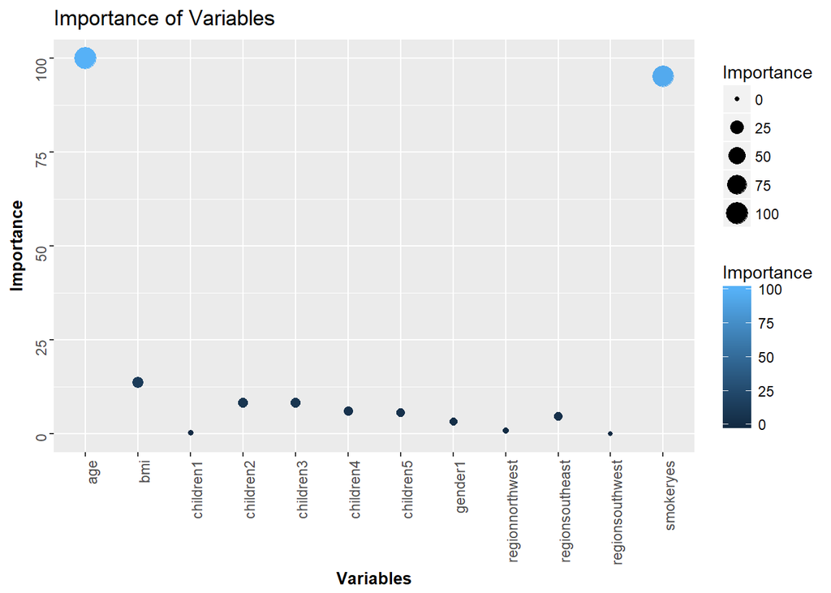

```r
################################## Random Forest Model ##################################################
caret.rf <- train(log(charges) ~ age+gender+bmi+children+smoker+region,
                  data = dataset.train,
                  method = "rf",
                  importance=T,
                  preProcess = c("center", "scale"),
                  trControl = train.control)

caret.rf.Imp <- varImp(caret.rf)
importance <- caret.rf.Imp$importance
##plot(caret.rf.Imp, top = 5)

varImportance <- data.frame(Variables = row.names(importance),
                            Importance = round(importance[ ,'Overall'],2))
#pdf("Variable importance.pdf")
impp <- ggplot(data=varImportance, aes(Variables,Importance,size=Importance,color=Importance))+
  geom_point()+
  theme(axis.text=element_text(angle = 90, hjust = 1),
        axis.title=element_text(size=10,face="bold"))
  print(impp + ggtitle("Importance of Variables"))
```

```r
#dev.off()
```

Ablation Analysis

```r
##################### Random Forest Model without sex   ############################
caret.rf.1 <- train(log(charges) ~ age+bmi+children+smoker+region,
                  data = dataset.train,
                  method = "rf",
                  importance=T,
                  preProcess = c("center", "scale"),
                  trControl = train.control)
```

```r
##################### Random Forest Model without smoker  ########################
caret.rf.2 <- train(log(charges) ~ age+bmi+children+region,
                  data = dataset.train,
                  method = "rf",
                  importance=T,
                  preProcess = c("center", "scale"),
                  trControl = train.control)
```